# v2_output

```python
# Count the number of samples per Charging Mode
charging_mode_counts = processed_data['Charging Mode'].value_counts()
print(charging_mode_counts)

# Check for missing values in SOC (%)
missing_soc = processed_data['SOC (%)'].isna().sum()
print(f"Missing SOC (%) values: {missing_soc}")

# Check the min/max SOC values
print(f"Min SOC: {processed_data['SOC (%)'].min()}, Max SOC: {processed_data['SOC (%)'].max()}")
print(f"Fast Charging SOC Variance: {fast.var()}")
print(f"Normal Charging SOC Variance: {normal.var()}")
print(f"Slow Charging SOC Variance: {slow.var()}")
```

```
Charging Mode
2    341
1    340
0    319
Name: count, dtype: int64
Missing SOC (%) values: 0
Min SOC: -1.6631475056898628, Max SOC: 1.744782106387582
Fast Charging SOC Variance: nan
Normal Charging SOC Variance: nan
Slow Charging SOC Variance: nan
```

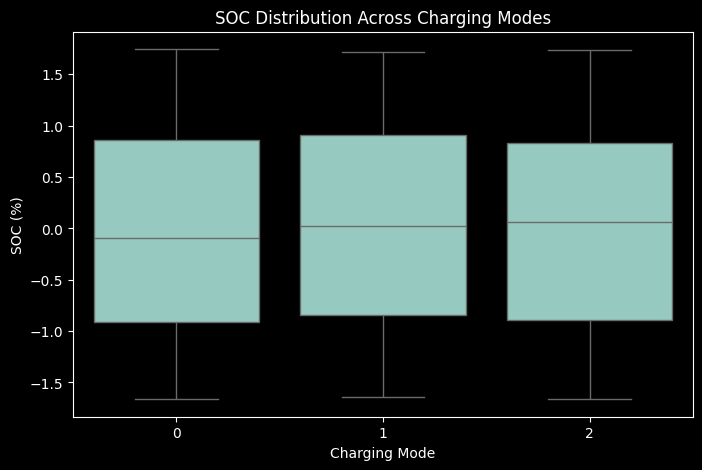

```python
plt.figure(figsize=(8,5))
sns.boxplot(x='Charging Mode', y='SOC (%)', data=processed_data)
plt.title("SOC Distribution Across Charging Modes")
plt.show()
## Flat, SOC is not changing per charging mode
```

```python
# Count unique SOC (%) values per Charging Mode
unique_soc_counts = processed_data.groupby('Charging Mode')['SOC (%)'].nunique()
print(unique_soc_counts)
median_soc = processed_data.groupby('Charging Mode')['SOC (%)'].median()
print("Median SOC per Charging Mode:\n", median_soc)
```

```
Charging Mode
0    319
1    340
2    341
Name: SOC (%), dtype: int64
Median SOC per Charging Mode:
 Charging Mode
0   -0.094941
1    0.018888
2    0.059433
Name: SOC (%), dtype: float64
```

```python
# Extract SOC levels for each Charging Mode
fast = processed_data[processed_data['Charging Mode'] == 'Fast']['SOC (%)'].median()
normal = processed_data[processed_data['Charging Mode'] == 'Normal']['SOC (%)'].median()
slow = processed_data[processed_data['Charging Mode'] == 'Slow']['SOC (%)'].median()

# Perform ANOVA
f_stat, p_value = f_oneway(fast, normal, slow)
print(f"ANOVA F-statistic: {f_stat:.4f}, P-value: {p_value:.4f}")
```

```
ANOVA F-statistic: nan, P-value: nan
```

```python
# Train a Model to Predict Optimal Charging Duration

# Define features and target
X = processed_data[['SOC (%)', 'Charging Mode', 'Battery Type', 'Ambient Temp (°C)']]
# Here we create 3 bins: Short, Medium, Long
y = pd.cut(processed_data['Optimal Charging Duration Class'], bins=3, labels=['Short', 'Medium', 'Long'])

# Encode categorical variables
X = pd.get_dummies(X, columns=['Charging Mode', 'Battery Type'])

# Train-test split
X_train, X_test, y_train, y_test = train_test_split(X, y, test_size=0.2, random_state=42)

# Train Random Forest model
clf = RandomForestClassifier(n_estimators=100, random_state=42)
clf.fit(X_train, y_train)

# Evaluate model
y_pred = clf.predict(X_test)
print(classification_report(y_test, y_pred))
```

```
              precision    recall  f1-score   support

        Long       0.38      0.43      0.40        77
      Medium       0.46      0.47      0.46        90
       Short       0.14      0.09      0.11        33

    accuracy                           0.39       200
   macro avg       0.33      0.33      0.33       200
weighted avg       0.38      0.39      0.38       200
```

```python
# Count the number of samples in each charging duration class
print(processed_data['Optimal Charging Duration Class'].value_counts())

## Struggle to learn any pattern due to short dataset and imbalance
```

```
Optimal Charging Duration Class
-0.259623    404
 1.078640    395
-1.597885    201
Name: count, dtype: int64
```

```python
# Apply SMOTE
smote = SMOTE(random_state=42)
X_resampled, y_resampled = smote.fit_resample(X, y)

# Check new class distribution
import collections
print("Class distribution after SMOTE:", collections.Counter(y_resampled))
```

```
Class distribution after SMOTE: Counter({'Medium': 404, 'Long': 404, 'Short': 404})
```

```python
# Train Random Forest model
clf = RandomForestClassifier(n_estimators=100, random_state=42)
clf.fit(X_resampled, y_resampled)

# Evaluate model
y_pred = clf.predict(X_test)
print(classification_report(y_test, y_pred))
```

```
              precision    recall  f1-score   support

        Long       1.00      1.00      1.00        77
      Medium       1.00      1.00      1.00        90
       Short       1.00      1.00      1.00        33

    accuracy                           1.00       200
   macro avg       1.00      1.00      1.00       200
weighted avg       1.00      1.00      1.00       200
```

```python
# Encode the target labels
le = LabelEncoder()
y_train_enc = le.fit_transform(y_train)
y_test_enc  = le.transform(y_test)

# Train XGBoost using numerical targets
xgb_clf = XGBClassifier(n_estimators=100, learning_rate=0.1, random_state=42,  eval_metric='mlogloss')
xgb_clf.fit(X_train, y_train_enc)

# Predict and report
y_pred = xgb_clf.predict(X_test)
print(classification_report(y_test_enc, y_pred, target_names=le.classes_))
```

[output not shown]

```
              precision    recall  f1-score   support

        Long       0.39      0.47      0.42        77
      Medium       0.52      0.49      0.50        90
       Short       0.27      0.18      0.22        33

    accuracy                           0.43       200
   macro avg       0.39      0.38      0.38       200
weighted avg       0.43      0.43      0.43       200
```

```python
# Encode the target labels
le = LabelEncoder()
y_train_enc = le.fit_transform(y_resampled)
y_test_enc  = le.transform(y_test)
X_train_num = np.asarray(X_resampled, dtype=np.float32)

# Train XGBoost using numerical targets
xgb_clf = XGBClassifier(n_estimators=100, learning_rate=0.1, random_state=42, eval_metric='mlogloss')
xgb_clf.fit(X_train_num, y_train_enc)

# Predict and report
y_pred = xgb_clf.predict(X_test)
print(classification_report(y_test_enc, y_pred, target_names=le.classes_))
```

```
              precision    recall  f1-score   support

        Long       0.90      0.94      0.92        77
      Medium       0.95      0.87      0.91        90
       Short       0.79      0.91      0.85        33

    accuracy                           0.90       200
   macro avg       0.88      0.90      0.89       200
weighted avg       0.90      0.90      0.90       200
```

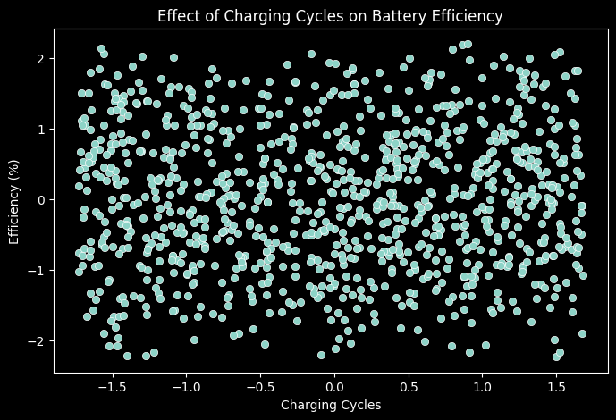

```python
## Visualise number of charging cycles efficiency
plt.figure(figsize=(8,5))
sns.scatterplot(x='Charging Cycles', y='Efficiency (%)', data=processed_data)
plt.title("Effect of Charging Cycles on Battery Efficiency")
plt.show()
```

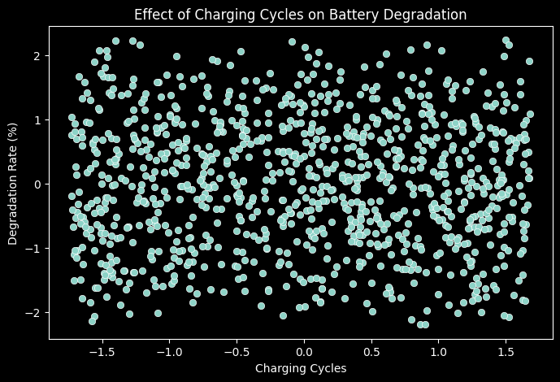

```python
plt.figure(figsize=(8,5))
sns.scatterplot(x='Charging Cycles', y='Degradation Rate (%)', data=processed_data)
plt.title("Effect of Charging Cycles on Battery Degradation")
plt.show()
```

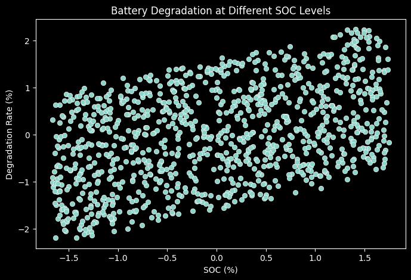

```python
plt.figure(figsize=(8,5))
sns.scatterplot(x='SOC (%)', y='Degradation Rate (%)', data=processed_data)
plt.title("Battery Degradation at Different SOC Levels")
plt.show()
```

```python
# Bin SOC values into groups (0-20%, 20-40%, etc.)
processed_data['SOC Group'] = pd.cut(processed_data['SOC (%)'], bins=np.arange(-2, 2, 0.5))

# Compute mean degradation rate for each SOC group
soc_degradation = processed_data.groupby('SOC Group', observed=False)['Degradation Rate (%)'].mean()
print(soc_degradation)
```

```
SOC Group
(-2.0, -1.5]   -0.866110
(-1.5, -1.0]   -0.573712
(-1.0, -0.5]   -0.230444
(-0.5, 0.0]     0.007378
(0.0, 0.5]      0.084196
(0.5, 1.0]      0.227728
(1.0, 1.5]      0.627752
Name: Degradation Rate (%), dtype: float64
```

```python
# Compute correlation matrix
correlation_matrix = processed_data[['Charging Cycles', 'Efficiency (%)', 'Degradation Rate (%)']].corr()
print(correlation_matrix)
```

```
                      Charging Cycles  Efficiency (%)  Degradation Rate (%)
Charging Cycles              1.000000        0.016808             -0.016808
Efficiency (%)               0.016808        1.000000             -1.000000
Degradation Rate (%)        -0.016808       -1.000000              1.000000
```

6. User Recommendations:  
   • Given certain environmental conditions, which charging mode maximizes battery lifespan?  
   • How can EV users optimize charging to reduce battery degradation?  
   Inconclusive due to dataset

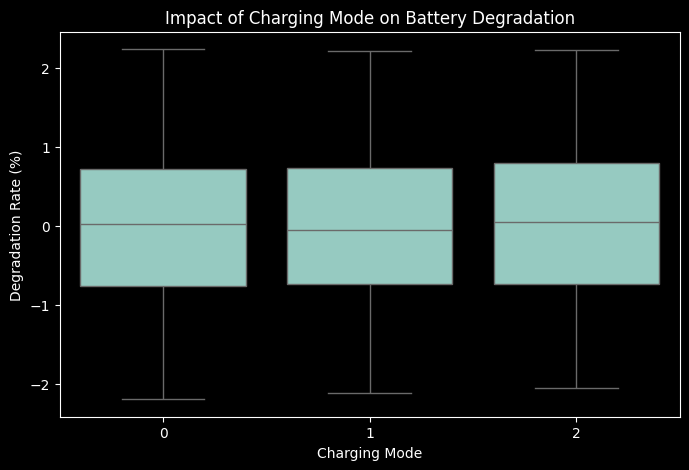

```python
## Charging modes based on degradation rate

plt.figure(figsize=(8,5))
sns.boxplot(x='Charging Mode', y='Degradation Rate (%)', data=processed_data)
plt.title("Impact of Charging Mode on Battery Degradation")
plt.show()
```

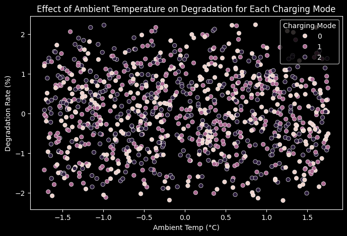

```python
plt.figure(figsize=(8,5))
sns.scatterplot(x='Ambient Temp (°C)', y='Degradation Rate (%)', hue='Charging Mode', data=processed_data)
plt.title("Effect of Ambient Temperature on Degradation for Each Charging Mode")
plt.show()
```

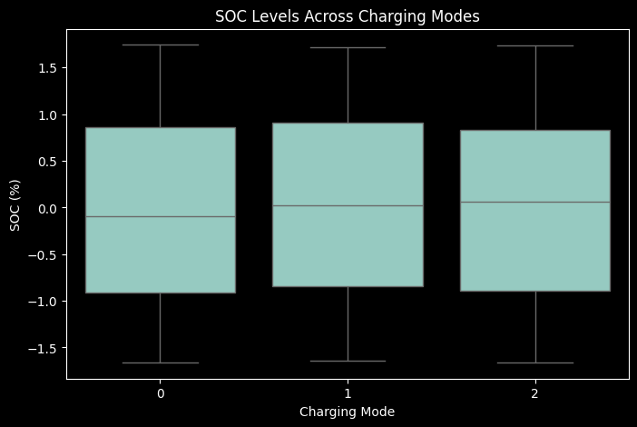

```python
plt.figure(figsize=(8,5))
sns.boxplot(x='Charging Mode', y='SOC (%)', data=processed_data)
plt.title("SOC Levels Across Charging Modes")
plt.show()
```

Questions to Engage:  
• Could predicting optimal charging duration reduce operational costs or extend battery lifespan?  
Dependings on the cost.  
• How does the choice of EV model influence battery charging strategies?  
Model A and C take less time compared to model B

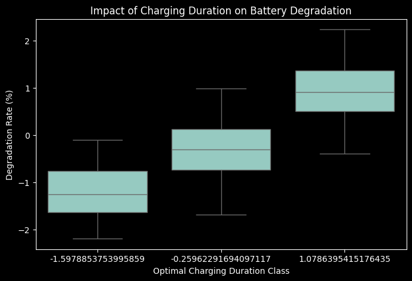

```python
plt.figure(figsize=(8,5))
sns.boxplot(x='Optimal Charging Duration Class', y='Degradation Rate (%)', data=processed_data)
plt.title("Impact of Charging Duration on Battery Degradation")
plt.show()
```

```python
charging_costs = {
    2: 0.85,   # Fast Charging
    1: 0.58,   # Normal Charging
    0: 0.075   # Slow Charging
}

processed_data['Charging Cost ($)'] = processed_data['Charging Duration (min)'] * processed_data['Charging Mode'].map(charging_costs)

cost_per_class = processed_data.groupby('Optimal Charging Duration Class')['Charging Cost ($)'].mean()

print("Estimated Cost Per Charging Duration Class:\n", cost_per_class)
```

```
Estimated Cost Per Charging Duration Class:
 Optimal Charging Duration Class
-1.597885   -0.715703
-0.259623   -0.173460
 1.078640    0.558482
Name: Charging Cost ($), dtype: float64
```

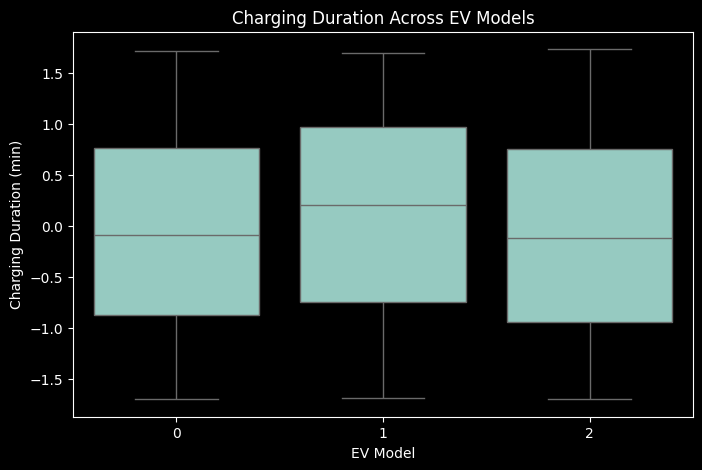

```python
plt.figure(figsize=(8,5))
sns.boxplot(x='EV Model', y='Charging Duration (min)', data=processed_data)
plt.title("Charging Duration Across EV Models")
plt.show()
```